# MPF: Trabajo Práctico 1, Parte B

Gonzalo Barrera Borla, Gerardo Mitas

November 1, 2016

## Setup Inicial

Antes de proceder con la resolución de las consignas, debemos cargar las librerías a utilizar, y el Marco Agropecuario:

```r
# Packages
library(sampling)
library(SamplingStrata)
library(dplyr)

# Cargo dataframe
load("data/Marco.Agropecuario.RData")
```

## Ejercicio 1

### Enunciado

Resolver la optimización por el algoritmo de Bethel empleando los 25 microestratos y las restricciones en CV a nivel Región o dominio detalladas.

### Respuesta

Para generar los 25 microestratos, debemos transformar las variables numéricas CANTEMP y SUPERFICIE en categóricas según pide el enunciado.

```r
# Creo las categorizazciones de CANTEMP y SUPERFICIE
# Para ello, comienzo asignando la categoria "superior" a todas las observaciones del Marco,
# y luego voy "pisando" este valor por default con las categorias "inferiores"
Marco.Agropecuario$catCANTEMP <- 5
Marco.Agropecuario$catCANTEMP <- ifelse(Marco.Agropecuario$CANTEMP <= 50, 4, Marco.Agropecuario$catCANTEMP)
Marco.Agropecuario$catCANTEMP <- ifelse(Marco.Agropecuario$CANTEMP <= 40, 3, Marco.Agropecuario$catCANTEMP)
Marco.Agropecuario$catCANTEMP <- ifelse(Marco.Agropecuario$CANTEMP <= 30, 2, Marco.Agropecuario$catCANTEMP)
Marco.Agropecuario$catCANTEMP <- ifelse(Marco.Agropecuario$CANTEMP <= 20, 1, Marco.Agropecuario$catCANTEMP)

Marco.Agropecuario$catSUPERFICIE <- 5
Marco.Agropecuario$catSUPERFICIE <- ifelse(Marco.Agropecuario$SUPERFICIE <= 2000, 4, Marco.Agropecuario$catSUPERFICIE)
Marco.Agropecuario$catSUPERFICIE <- ifelse(Marco.Agropecuario$SUPERFICIE <= 1500, 3, Marco.Agropecuario$catSUPERFICIE)
Marco.Agropecuario$catSUPERFICIE <- ifelse(Marco.Agropecuario$SUPERFICIE <= 1000, 2, Marco.Agropecuario$catSUPERFICIE)
Marco.Agropecuario$catSUPERFICIE <- ifelse(Marco.Agropecuario$SUPERFICIE <= 500, 1, Marco.Agropecuario$catSUPERFICIE)
```

El siguiente bloque de código permite comprobar manualmente que las variables estén correctamente categorizadas:

```r
sample_n(Marco.Agropecuario, 20)[,c("SUPERFICIE","catSUPERFICIE")]
sample_n(Marco.Agropecuario, 20)[,c("CANTEMP","catCANTEMP")]
```

Luego, debemos renombrar las variables estratificadores y objetivo de modo que la función `bethel` (y más adelante `optimizeStrata`) entienda. También agregamos la variable de control `domainvalue`: aunque vamos a trabajar con 3 dominios por separado, para evitarle confusiones al algoritmo todas las observaciones reciben el mismo valor de `domainvalue`.

```r
# Copio, renombro y transformo en factor las variables estratificadoras
Marco.Agropecuario$X1 <- as.factor(Marco.Agropecuario$catCANTEMP)
Marco.Agropecuario$X2 <- as.factor(Marco.Agropecuario$catSUPERFICIE)

# Copio y renombro las variables objetivo
Marco.Agropecuario$Y1 <- Marco.Agropecuario$SOJA
Marco.Agropecuario$Y2 <- Marco.Agropecuario$TRIGO
Marco.Agropecuario$Y3 <- Marco.Agropecuario$BOVINOS

# Variable de control necesara para la optimizacion de estratos
Marco.Agropecuario$domainvalue = 1
```

Pretendemos encontrar óptimos por dominio, tarea para la cual `bethel` tiene algunas dificultades técnicas. Por ello, separaremos el Marco Agropecuario en 3 marcos según la región de sus Unidades: Norte, Centro y Sur:

```r
Norte <- Marco.Agropecuario[Marco.Agropecuario$REGION==1,]
Centro <- Marco.Agropecuario[Marco.Agropecuario$REGION==2,]
Sur <- Marco.Agropecuario[Marco.Agropecuario$REGION==3,]
```

Creamos un diminuto data frame con la información sobre los CV objetivo por variable, para cada región.

```r
DOM <- "DOM1"
CV1 <- 0.02
CV2 <- 0.01
CV3 <- 0.02
domainvalue <- 1
CVNorte <- data.frame(DOM,CV1,CV2,CV3,domainvalue)

CV1 <- 0.01
CV2 <- 0.01
CV3 <- 0.02
CVCentro <- data.frame(DOM,CV1,CV2,CV3,domainvalue)

CV1 <- 0.05
CV2 <- 0.03
CV3 <- 0.05
CVSur <- data.frame(DOM,CV1,CV2,CV3,domainvalue)
```

Como último paso de preparación, computamos la información auxiliar que el algoritmo exige para ejecutar la optimización.

```r
resumenNorte <- buildStrataDF(Norte)
```

```
##
## Computations have been done on population data
```

```r
resumenCentro <- buildStrataDF(Centro)
```

```
##
## Computations have been done on population data
```

```r
resumenSur <- buildStrataDF(Sur)
```

```
##
## Computations have been done on population data
```

Finalmente, podemos resolver la optimización por el algoritmo de Bethel

```r
soluNorte <- bethel(resumenNorte,CVNorte,printa=TRUE)
soluCentro <- bethel(resumenCentro,CVCentro,printa=TRUE)
soluSur <- bethel(resumenSur,CVSur,printa=TRUE)
```

## Ejercicio 2

### Enunciado

Si el algoritmo convergió, por dominio analizar y comprobar si existen estratos con Nh<=10 y/o nh <=4 y/o los que el algoritmo propone como “censo” por dominio de estimación. Se sugiere presentar en una tabla con los resultados del óptimo por dominio y estrato, con sus tamaños poblacionales, muestrales. Completar la tabla con las probabilidades π k y agregar un resumen con los tamaños muestrales por dominio y los CV alcanzados vs. los propuestos.

### Respuesta

La información auxiliar que provee la implementación del algoritmo de Bethel que estamos utilizando es poco maleable. Para analizarla más cómodamente, escribimos dos funciones auxilares. Dado el output de una corrida de `bethel` con `printA=TRUE`,

- **tablaCV** provee una tabla comparativa de los CV esperados/objetivos con los CV alcanzados
- **tablaEstratos** provee una tabla con los $N_{h}$, $n_{h}$ y $\pi_{k}$ por estrato y globales

```r
tablaCV <- function (solucion) {
  tempResult <- data.frame(attr(soluSur,"outcv")[,c(2,3,4)])

  tempResult$variable <- c("SOJA","TRIGO","BOVINOS")
  tempResult$plannedCV <- as.numeric(as.character(tempResult$PLANNED.CV))
  tempResult$actualCV <- as.numeric(as.character(tempResult$ACTUAL.CV))

  result <- tempResult[,c("variable","plannedCV","actualCV")]
  return(result)
}
```

```r
tablaEstratos <- function(solucion) {
  tempResult <- data.frame(attr(solucion,"confr")[,c(1,2,3)])

  tempResult$Nh <- as.numeric(as.character(tempResult$POPULATION))
  tempResult$nh <- as.numeric(as.character(tempResult$BETHEL))
  tempResult$Pik <- tempResult$nh/tempResult$Nh

  result <- tempResult[,c("STRATUM","Nh","nh","Pik")]
  return(result)
}
```

El enunciado también pide analizar si existen estratos con $N_{h}<=10$, $n_{h}<=4$ o “censos” (es decir, donde los individuos del estrato participan de la muestra con probabilidad 1, $\pi_{k}=1$. Podríamos realizar esta tarea a mano, pero también podemos encargársela a una función que filtre el output de `tablaEstratos`:

```r
malosEstratos <- function(tablaEstratos) {
  result <- tablaEstratos[tablaEstratos$Nh<=10 |
                            tablaEstratos$nh<=4 |
                            tablaEstratos$Pik==1,]
  return(result)
}
```

Luego, creamos las tablas resumen para cada dominio, e inspeccionamos su contenido:

```r
tablaCVNorte <- tablaCV(soluNorte)
tablaCVCentro <- tablaCV(soluCentro)
tablaCVSur <- tablaCV(soluSur)

tablaEstratosNorte <- tablaEstratos(soluNorte)
tablaEstratosCentro <- tablaEstratos(soluCentro)
tablaEstratosSur <- tablaEstratos(soluSur)
```

#### Dominio “Norte”

##### CVs alcanzados versus esperados

[output not shown]

##### Resumen por estrato

```
##    STRATUM   Nh   nh       Pik
## 1      1*1   41   13 0.3170732
## 2      1*2  185   53 0.2864865
## 3      1*3  291   85 0.2920962
## 4      1*4  298   89 0.2986577
## 5      1*5  212  108 0.5094340
## 6      2*1  108   28 0.2592593
## 7      2*2  456  126 0.2763158
## 8      2*3  710  203 0.2859155
## 9      2*4  634  193 0.3044164
## 10     2*5  423  169 0.3995272
## 11     3*1   86   27 0.3139535
## 12     3*2  411  117 0.2846715
## 13     3*3  611  178 0.2913257
## 14     3*4  563  173 0.3072824
## 15     3*5  387  132 0.3410853
## 16     4*1   39   10 0.2564103
## 17     4*2  224   65 0.2901786
## 18     4*3  312   94 0.3012821
## 19     4*4  240   72 0.3000000
## 20     4*5  212   86 0.4056604
## 21     5*1   22    5 0.2272727
## 22     5*2  120   29 0.2416667
## 23     5*3  188   54 0.2872340
## 24     5*4  181   55 0.3038674
## 25     5*5  113   37 0.3274336
## 26   TOTAL 7067 2201 0.3114476
```

##### Lista de estratos inestables:

```
## [1] STRATUM Nh      nh      Pik
## <0 rows> (or 0-length row.names)
```

#### Dominio “Centro”

##### CVs alcanzados versus esperados

[output not shown]

##### Resumen por estrato

```
##    STRATUM   Nh   nh       Pik
## 1      1*1   11    2 0.1818182
## 2      1*2  111   22 0.1981982
## 3      1*3  257   66 0.2568093
## 4      1*4  304  104 0.3421053
## 5      1*5  328  252 0.7682927
## 6      2*1   31    4 0.1290323
## 7      2*2  208   35 0.1682692
## 8      2*3  577  155 0.2686308
## 9      2*4  641  211 0.3291732
## 10     2*5  845  655 0.7751479
## 11     3*1   29    4 0.1379310
## 12     3*2  187   33 0.1764706
## 13     3*3  442  106 0.2398190
## 14     3*4  521  172 0.3301344
## 15     3*5  711  558 0.7848101
## 16     4*1   13    2 0.1538462
## 17     4*2  113   20 0.1769912
## 18     4*3  232   70 0.3017241
## 19     4*4  305  102 0.3344262
## 20     4*5  335  229 0.6835821
## 21     5*1   10    2 0.2000000
## 22     5*2   71   14 0.1971831
## 23     5*3  163   39 0.2392638
## 24     5*4  175   54 0.3085714
## 25     5*5  215  159 0.7395349
## 26   TOTAL 6835 3070 0.4491587
```

##### Lista de estratos inestables:

```
##    STRATUM Nh nh       Pik
## 1      1*1 11  2 0.1818182
## 6      2*1 31  4 0.1290323
## 11     3*1 29  4 0.1379310
## 16     4*1 13  2 0.1538462
## 21     5*1 10  2 0.2000000
```

#### Dominio “Sur”

##### CVs alcanzados versus esperados

```
##   variable plannedCV actualCV
## 1     SOJA      0.05   0.0432
## 2    TRIGO      0.03   0.0293
## 3  BOVINOS      0.05   0.0430
```

##### Resumen por estrato

```
##    STRATUM   Nh  nh       Pik
## 1      1*1    3   2 0.6666667
## 2      1*2   18   2 0.1111111
## 3      1*3   44   9 0.2045455
## 4      1*4   81  12 0.1481481
## 5      1*5  189  26 0.1375661
## 6      2*1    5   2 0.4000000
## 7      2*2   34   7 0.2058824
## 8      2*3  111  15 0.1351351
## 9      2*4  139  21 0.1510791
## 10     2*5  447  58 0.1297539
## 11     3*1    4   2 0.5000000
## 12     3*2   23   3 0.1304348
## 13     3*3   93  14 0.1505376
## 14     3*4  139  21 0.1510791
## 15     3*5  352  50 0.1420455
## 16     4*1    2   2 1.0000000
## 17     4*2   18   2 0.1111111
## 18     4*3   37   8 0.2162162
## 19     4*4   67  10 0.1492537
## 20     4*5  174  22 0.1264368
## 21     5*1    1   1 1.0000000
## 22     5*2    5   2 0.4000000
## 23     5*3   17   3 0.1764706
## 24     5*4   39   6 0.1538462
## 25     5*5  106  13 0.1226415
## 26   TOTAL 2148 313 0.1457169
```

##### Lista de estratos inestables:

```
##    STRATUM Nh nh       Pik
## 1      1*1  3  2 0.6666667
## 2      1*2 18  2 0.1111111
## 6      2*1  5  2 0.4000000
## 11     3*1  4  2 0.5000000
## 12     3*2 23  3 0.1304348
## 16     4*1  2  2 1.0000000
## 17     4*2 18  2 0.1111111
## 21     5*1  1  1 1.0000000
## 22     5*2  5  2 0.4000000
## 23     5*3 17  3 0.1764706
```

## Ejercicio 3

### Enunciado

Resolver la optimización por el algoritmo de Genético buscando reagrupar con un criterio óptimo a los 25 microestratos por dominio, imponiendo la condición que la nueva estratificación no supere los 10 estratos, una restricción tal que $n_{h}>=5$ en cada estrato y bajo los mismos CV a nivel Región empleados para el algoritmo de Bethel. Teniendo en cuenta que el algoritmo puede llevar a mínimos locales, se propone estudiar y presentar no menos de 3 alternativas modificando algunos parámetros que por default propone el algoritmo (`pops`, `iter`, `mut_chance` y `elitism_rate`) antes de quedarse con aquella que responde a las precisiones deseadas y al menor tamaño de muestra final alcanzado por samplingStrata1.

### Respuesta

A diferencia de `bethel`, la rutina `optimizeStrata` sí es capaz de lidiar correctamente con requerimientos de CV variantes por dominio. Por ello, para esta segunda optimización, podemos utilizar el Marco Agropecuario completo, siempre y cuando agreguemos `REGION` como variable estratificadora y de dominio:

```r
Marco.Agropecuario$X3 <- as.factor(Marco.Agropecuario$REGION)
Marco.Agropecuario$domainvalue <- Marco.Agropecuario$REGION
```

Para ejecutar la optimización por algoritmo genético, debemos pasar, al igual que a `bethel`, los resultados de `buildstrata` junto con una tabla con las precisiones por variable objetivo y dominio:

```
##
## Computations have been done on population data
```

```
##    DOM  CV1  CV2  CV3 domainvalue
## 1 DOM1 0.02 0.01 0.02           1
## 2 DOM1 0.01 0.01 0.02           2
## 3 DOM1 0.05 0.03 0.05           3
```

Se pretende realizar una exploración del espacio de parametrización de `optimizeStrata`, en particular sobre `pops`, `iter`, `mut_chance` y/o `elitism_rate`, con no menos de 3 combinaciones posibles. Dado que cada corrida del algoritmo es costosa en términos de tiempo, no podemos probar infinitas posibilidades. A su vez, nos gustaría que aunque sea pocas, las corridas que realicemos nos provean de alguna información accionable sobre el comportamiento del algoritmo.

A priori, es de esperar que el mínimo que alcanza una corrida sea decreciente en la cantidad de iteraciones, y el tamaño de la población: puede que la corrida en sí tarde más, pero el resultado final no puede empeorar al aumentar `pops` o `iter`. Por ello, fijaremos ambos parámetros en valores bastante más altos que los default, y exploraremos en los otros dos. Usaremos `pops=100` e `iter=200` (versus 20 de default en ambos).

Correr `optimizeStrata`, actualizar los estratos y el marco original, evaluar los resultados… son demasiados pasos para realizar a mano en cada corrida. Para evitar errores manuales, hemos escrito la siguiente rutina, `probarParametros`, que toma un par de valores para `mut_chance` y `elitism_rate`, y

1. corre `optimizeStrata` con los valores default que exige el ejercicio, los que hemos fijate para `pops` e `iter`, y los que reciba como parámetros, y guarda el resultado;
2. con la solución obtenida, actualiza las estratificaciones tanto del resumen del Marco generado por `buildStrataDF` como del Marco Agreopecuario en sí;
3. genera dos tablas resumen,
   - una con las opciones variables empleadas, más la cantidad de estratos y el tamaño muestral alcanzado por dominio y en general,
   - otra con los CV esperados y alcanzados; y
4. Evalúa la solución en un conjunto de 100 muestras tomadas al azar.

Además, guarda todos los objetos resultado de estas manipulaciones en una lista que devuelve al terminar de correr:

```r
probarParametros <- function(mut_chance, elitism_rate) {

  # Lista con resultados
  prueba <- list()

  # Solucion por algoritmo genético
  prueba$solu <- optimizeStrata(strata=resumenMarco,
                                errors=CVobjetivo,
                                iter=200,
                                pops=100,
                                initialStrata=5,
                                mut_chance=mut_chance,
                                elitism_rate=elitism_rate,
                                minnumstr=5,
                                writeFiles=TRUE)

  # Actualización de la data en función de los nuevos agrupamientos de estratos
  prueba$nuevosEstratos <- updateStrata(resumenMarco, prueba$solu, writeFile=TRUE)
  prueba$nuevoMarco <- updateFrame(Marco.Agropecuario,prueba$nuevosEstratos)

  # Resumen aspectos centrales de la corrida
  prueba$resumen <- data.frame(mut_chance,elitism_rate)
  prueba$resumen <- cbind(prueba$resumen,t(tapply(prueba$solu$aggr_strata$STRATO,prueba$solu$aggr_strata$DOM1,function(x) length(unique(x)))))
  prueba$resumen <- cbind(prueba$resumen,t(tapply(prueba$solu$aggr_strata$SOLUZ,prueba$solu$aggr_strata$DOM1,sum)))
  colnames(prueba$resumen) <- c("mut_chance","elitism_rate","hNorte","hCentro","hSur","nNorte","nCentro","nSur")
  prueba$resumen$H <- prueba$resumen$hNorte + prueba$resumen$hCentro + prueba$resumen$hSur
  prueba$resumen$N <- prueba$resumen$nNorte + prueba$resumen$nCentro + prueba$resumen$nSur

  # Evaluación de la solución
  prueba$eval <- evalSolution(prueba$nuevoMarco,prueba$solu$aggr_strata,nsampl=100,writeFiles=TRUE)

  # CVs objetivos y CVs alcanzados en la evaluación
  prueba$CVesperado <-read.csv("expected_cv.csv")
  prueba$CVesperado <- cbind(prueba$CVesperado,CVobjetivo)

  return(prueba)
}
```

Ya de por sí, la función recién definida nos ahorrará buena cantidad de trabajo, pero todavía tenemos un problema: sus ejecuciones generan una enorme cantidad de archivos auxiliares, que deseamos conservar en conjunto con el objeto acumulador de resultados que definimos. Además, ni `optimizeStrata` ni `evalSolution` proveen formas fáciles de cambiar programáticamente el nombre de los archivos que outputean.

1. crea (si no la hay ya), una carpeta con el nombre `pruebaX`, y en cualquier caso la elige como directorio de trabajo,
2. corre la función anterior, `probarParametros`, de modo que los archivos auxiliares generados estén en su propio directorio,
3. salva el objeto que devuelve la i-ésima prueba en el i-ésimo lugar de una lista, para poder comparar todas las corridas más tarde, y
4. finalmente, vuelve al directorio de trabajo original.

Esta rutina es el núcleo de este trabajo, y toma no menos de dos horas aún en una PC poderosa, por lo tanto no se la evalúa en este momento, sino que sus resultados están guardados en el archivo `parteB.RData`.

```r
pruebas <- list()

for (i in 1:6) {
  row <- parametrosAProbar[i,]
  dirname <- as.character(row$dirname)
  # Creo un directorio para los archivos de trabajo si aun no existe
  dir.exists(dirname) || dir.create(dirname)
  setwd(dirname)

    pruebas[[i]] <- probarParametros(mut_chance = row$mut_chance,
                                 elitism_rate = row$elitism_rate)
  setwd("..")
}
```

## Ejercicio 4 y 5

### Enunciado

Presentar para cada solución o estratificación un resumen con:

- Los parámetros u opciones empleadas en el algoritmo
- El total de estratos en cada dominio
- Tamaños muestrales alcanzados y por dominio

Proponer a su criterio una estratificación de las estudiadas como “definitiva”, acompañándola con una síntesis con los motivos que llevaron a elegirla, más los gráficos de convergencia (plotdom1.pdf-plotdom3.pdf). Comparar los tamaños de muestra total por dominio con los propuestos por Bethel.

### Respuesta

Utilizando el dataframe `resumen` que devuelve, entre otros, `probarParametros`, podemos comparar rápidamente los resultados de nuestras seis corrida:

```
##   mut_chance elitism_rate hNorte hCentro hSur nNorte nCentro nSur  H    N
## 1       0.05          0.1     13      11   10   2193    3063  296 34 5552
## 2       0.05          0.2     15      15   10   2194    3060  295 40 5549
## 3       0.10          0.1     15      13    7   2195    3061  296 35 5552
## 4       0.10          0.2     12      19    9   2194    3062  296 40 5552
## 5       0.20          0.1     13      17    8   2197    3072  295 38 5564
## 6       0.20          0.2     18      12    9   2196    3074  295 39 5565
```

De esta comparación, lo primera que llama la atención, es que $N$ es básicamente idéntico para las seis pruebas: la razón entre el menor y mayor valor es de $5565/5549=1.0029$, una diferencia de 0,3%.

Lo que no es evidente a partir de esta tabla, es si todos los N se parecen tanto entre sí porque:

- efectivamente estamos en o cerca del mínimo global (y no es posible obtener los CV deseados con un N menor),
- hemos sido muy tímidos en la exploración de parámetros, o
- la estratificación propuesta no está aportando demasiado a la reducción del $N$ global en comparación con un método menos sofisticado.

También es interesante notar que ,aunque puede ser pura coincidencia (pues todos los N están bastante apretados entre sí), el menor le corresponde a la **prueba 2**, en la cual utilizamos **los valores por default de `mut_chance` y `elitism_rate`**.

Obervemos ahora los gráfico de convergencia por dominio:

#### Convergencia Dominio Norte

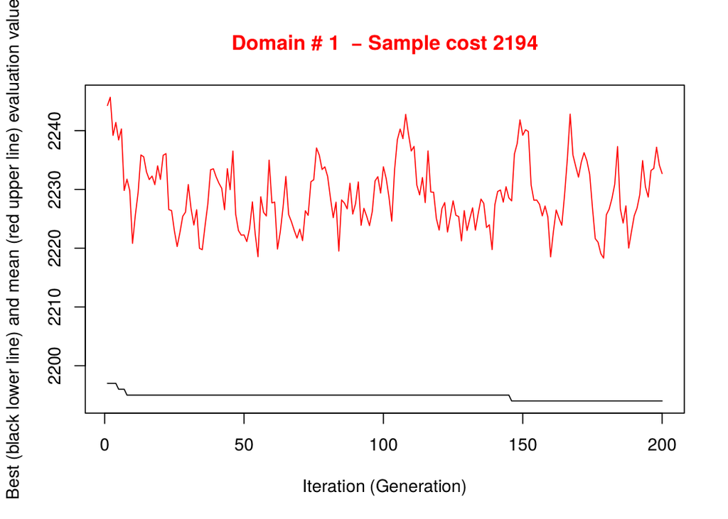

Convergencia Dominio Norte

#### Convergencia Dominio Centro

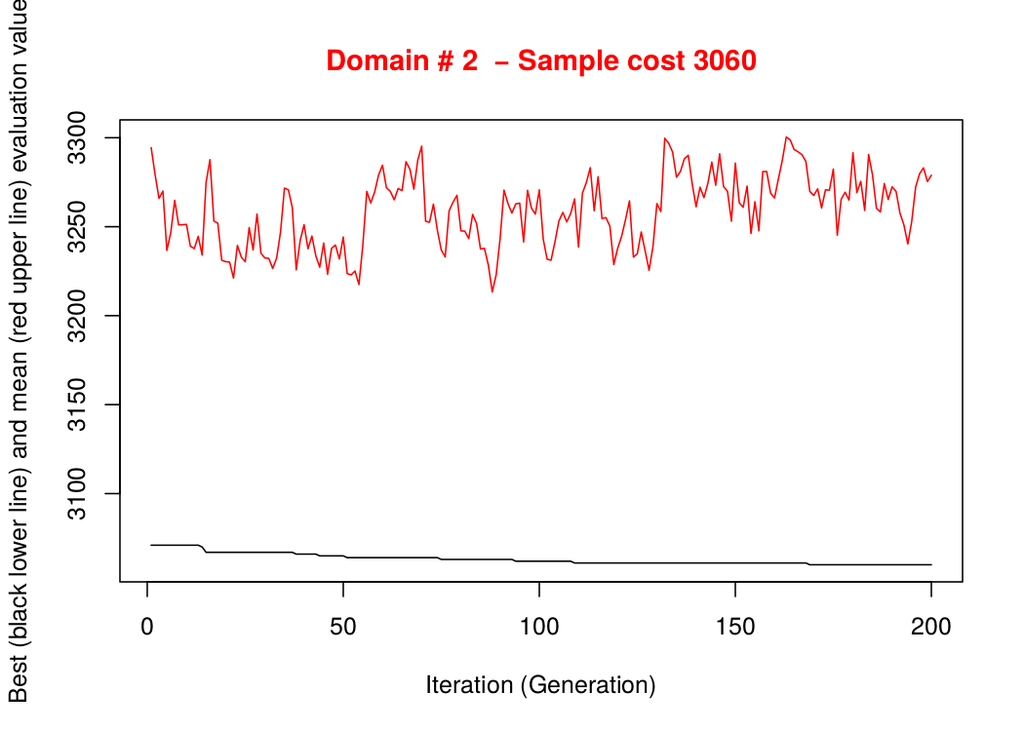

Convergencia Dominio Centro

#### Convergencia Dominio Sur

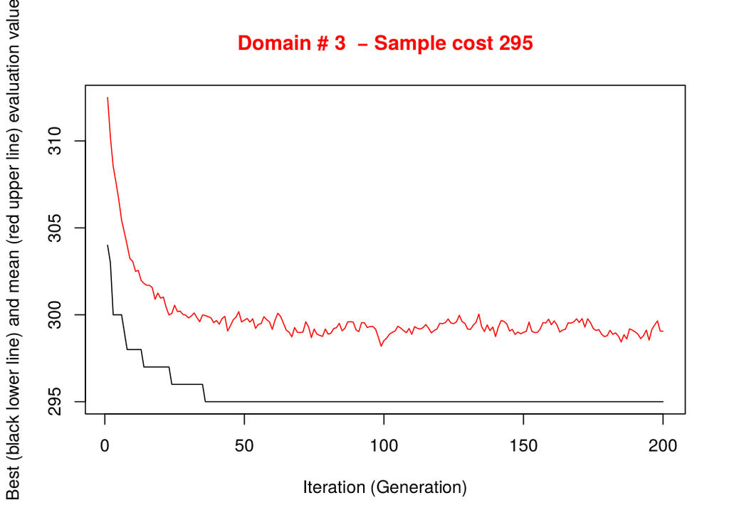

Convergencia Dominio Sur

Es destacable que en los dominios Norte y Centro, que son por mucho los más extensos, el mínimo costo de cada población disminuye ínfimamente o directamente no disminuye de una corrida a la siguiente, mientras que el promedio ni siquiera pareciese estar convergiendo.

Por otra parte, en el dominio Sur sí se observa una convergenia del costo medio por población hacia un valor estable alrededor de 300, y el mínimo ya ha convergido a 295 aún antes de la iteración 50.

En otras palabras, es posible que los parámetros elegidos para correr el algoritmo genético sean válidos para poblaciones del tamaño del Dominio Sur, pero resulten absolutamente inadecuados para poblaciones un orden de magnitud mayor, como lo son los dominios Norte y Centro.

Finalmente, puede resultar ilustrativo comparar los N por dominio de la prueba 2 con los obtenidos más temprano con Bethel:

```
##          nNorte nCentro nSur N
## bethel   2201   3070    313  5584
## genetico 2194   3060    295  5549
```

Viendo estos resultados, y considerando que la estratificación genética es muy “sintética” (agrupa segmentos discontinuos de la población subyacente), como asesor de los organizadores de la encuesta, recomendaría **mantener la estratificación base de Bethel, agrupando estratos continuos únicamente para eliminar aquellos que son inestables según el análisis del Ejercicio 2**. Este trabajo, sin embargo, cae ya fuera dela órbita de este Informe.

## Ejercicio 6 y 7

### Enunciado

Presentar la tabla de conversión de los estratos originales en los definitivos en cada dominio señalando en la microestratificación cómo quedaron agrupados.

Actualizar el marco muestral con los nuevos estratos.

### Respuesta

El marco muestral fue actualizado con los nuevos estratos por la función `probarParametros`:

```r
# ... más código ...
prueba$nuevosEstratos <- updateStrata(resumenMarco, prueba$solu, writeFile=TRUE)
prueba$nuevoMarco <- updateFrame(Marco.Agropecuario,prueba$nuevosEstratos)
# ... aún más código...
```

Si se revisa el elemento `pruebas[[2]]$nuevosEstratos`, se peuden observar las relaciones entre los viejos estratos (`STRATO`) y los nuevos (por combinación de `DOM1` y `LABEL`).

```r
sample_n(pruebas[[2]]$nuevosEstratos[c("STRATO","DOM1","LABEL")],5)
```

```
##    STRATO DOM1 LABEL
## 72  5*2*3    3     2
## 44  4*4*2    2    12
## 1   1*1*1    1     1
## 46  5*1*2    2    14
## 13  3*3*1    1    11
```

Sin embargo, revisar a mano a relación entre una estratificación de 75 microestratos y otra de 40 “miniestratos” es hilar demasiado fino como para obtener información útil. En su lugar, proponemos utilizar algunas de las capacidades del package `dplyr`, que nos permite agrupar y resumir información de maneras convenientes. A continuación entonces, se encuentra el código para agrupar el nuevo Marco de modo que para cada uno de los 40 estratos derivados del algoritmo genético, veamos:

- a qué `dominio` corresponde,
- qué `nuevoIdEstrato` tiene dentro del dominio,
- la población total dentro del nuevo estrato, y
- a cuántos viejos estratos agrupa

```r
nm <- pruebas[[2]]$nuevoMarco
grouped_nm <- group_by(nm, DOMAINVALUE, LABEL)
sumario <- summarise(grouped_nm, pop = n(), no_estratos = n_distinct(STRATUM))
sumario <- as.data.frame(sumario)
colnames(sumario) <- c("dominio","nuevoIdEstrato","nuevoNh","cantEstratosAgrupados")
sumario
```

```
##    dominio nuevoIdEstrato nuevoNh cantEstratosAgrupados
## 1        1              1     339                     2
## 2        1              2    1307                     4
## 3        1              3     494                     3
## 4        1              4     212                     1
## 5        1              5     147                     2
## 6        1              6     456                     1
## 7        1              7    1197                     2
## 8        1              8     423                     1
## 9        1              9     206                     2
## 10       1             10     411                     1
## 11       1             11     611                     1
## 12       1             12     500                     2
## 13       1             13     312                     1
## 14       1             14     240                     1
```

[output cut: 26 more lines]

Para finalizar, hacemos un tabla con la cantidad de microestratos que agrupa cada nuevo estrato, para hacernos una idea de cuánto hemos “comprimido” la estratificación original:

```r
table(sumario$cantEstratosAgrupados)
```

```
##
##  1  2  3  4
## 16 14  9  1
```

## Ejercicio 8

### Enunciado

Evaluar el comportamiento de los CV y las estimaciones de cada variable objetivo en cada dominio a través de una simulación con 1000 muestras seleccionadas del marco muestral empleando el comando evalSolution() del Package. Interpretar y brindar una explicación de los resultados que exporta: cv.pdf, differences.pdf o differences.csv.

### Respuesta

```r
setwd("prueba2")
# Evaluación de la solución
pruebas[[2]]$eval <- evalSolution(pruebas[[2]]$nuevoMarco,pruebas[[2]]$solu$aggr_strata,nsampl=100,writeFiles=TRUE)

# CVs objetivos y CVs alcanzados en la evaluación
pruebas[[2]]$CVesperado <-read.csv("expected_cv.csv")
pruebas[[2]]$CVesperado <- cbind(pruebas[[2]]$CVesperado,CVobjetivo)
setwd("..")
pruebas[[2]]$CVesperado
```

[output not shown]

Leyendo de la ayuda de `evalSolution`, podemos ver que:

> First, the true values of the parameters are calculated from the frame. Then, for each sample the sampling estimates are calculated, together with the differences between them and the true values of the parameters. At the end, an estimate of the CV is produced for each target variable, in order to compare them with the precision constraints set at the beginning of the optimization process. If the flag ‘writeFiles’ is set to TRUE, boxplots of distribution of the CV’s in the different domains are produced for each Y variable (‘cv.pdf’), together with boxplot of the distributions of differences between estimates and values of the parameters in the population (‘differences.pdf’).

- `dom`: el dominio en el que se calculan las diferencias entre los valores verdaderos de las variables objetivos y la muestra seleccionada,
- `samp`: el número de muestra aleatoria de evaluación,
- `diff[1|2|3]`: la differencia entre el valor real y el obtenido en la muestra para la variable objetivo (1:SOJA, 2:TRIGO, 3:BOVINOS)

A partir de esta información, se generan boxplots de las diferencias registradas en `differences.csv`. Como estas diferencias están expresadas en valores absolutos, su escala depende muchísimo del rango en que se encuentran los valores de la variable original, y no proveen, a simple vista, mucha información.

El tercer archivo, `cv.pdf`, es más interesante, ya que ver el rango intercuartil del CV esperado por variable nos da una visión más acabada del comportamiento que de ellas podemos esperar. Lamentablemente, por alguna misteriosa razón, el output sólo incluye gráficos para los CV de las variables a estudiar en el dominio número 1 (“Norte”).

## Ejercicio 9

### Enunciado

Seleccionar una muestra según la solución definitiva empleando el comando `selectSample` del Package.

### Respuesta

Aquí no hay mucho que hacer más que:

```r
muestra <- selectSample(pruebas[[2]]$nuevoMarco,pruebas[[2]]$solu$aggr_strata, writeFiles=TRUE)
```

```
##
## *** Sample has been drawn successfully ***
##  5549  units have been selected from  40  strata
```

## Ejercicio 10

### Enunciado

Presentar una tabla resumen con las probabilidades $\pi_{k}$ y las $\pi_{kl}$ del diseño final adoptado.

### Respuesta

Dado que el Marco Agropecuario tiene más de 16.000 entradas, y se nos pide una tabla **resumen** de las probabilidades de inclusión, no vamos a ofrecer aquí ni el vector con las 16.050 probabilidades de primer orden ni la matriz con las 16.050^2 probabilidades de segundo orden.

En `pruebas[[2]]$solu$aggr_strata` podemos encontrar los tamaños poblacionales y por estrato que le corresponden a cada uno de los nuevos 40 estratos. A partir de ellos, y sabiendo que dentro de cada estrato los individuos de la muestra se eligen por MSA, es sencillo calcular las 40 $\pi_{k}$ por nuevos estratos.

Un poco más complejo, es calcular las $\pi_{kl}$ de forma resumida, pues hay que considerar varios casos:

1. si $k=l$, entonces $\pi_{kl}=\pi_{kk}=\pi_{k}$
2. si $h(k) = h(l) = h$ y $k \neq l$, entonces $\pi_{kl}=\frac{n_{h}}{N_{h}}\frac{n_{h}-1}{N_{h}-1}$
3. si $h(k)\neq h(l)$, entonces $\pi_{kl}=\pi_{k}\pi_{l}$

Dado que el caso 1 se puede observar en el vector de $\pi_{k}$’s, y el caso 2 se puede aproximar como el caso 3 cuando $n_{h}$ y $N_{h}$ son lo suficientemente grandes, consideramos que proveer el vector con las 40 $\pi_{k}$ y las 40x40 $\pi_{kl}$ del caso 3 son una aproximación suficiente a los requerimientos de este ejercicio. Eso, y en algún momento tengo que dejar de escribir y comenzar a editar este trabajo.

```r
agr_strata <- pruebas[[2]]$solu$aggr_strata
agr_strata$nh <- agr_strata$SOLUZ
agr_strata$Nh <- agr_strata$N
agr_strata$Pik <- agr_strata$nh / agr_strata$Nh

vector_piks <- agr_strata$Pik
matriz_pikls <- vector_piks %*% t(vector_piks)

# Muestro un fragmento de los vectores:
vector_piks[1:5]
```

```
## [1] 0.2979351 0.2853864 0.2914980 0.5141509 0.2517007
```

```r
matriz_pikls[1:5,1:5]
```

```
##            [,1]       [,2]       [,3]      [,4]       [,5]
## [1,] 0.08876533 0.08502662 0.08684748 0.1531836 0.07499047
## [2,] 0.08502662 0.08144539 0.08318955 0.1467317 0.07183195
## [3,] 0.08684748 0.08318955 0.08497107 0.1498740 0.07337024
## [4,] 0.15318361 0.14673168 0.14987396 0.2643512 0.12941214
## [5,] 0.07499047 0.07183195 0.07337024 0.1294121 0.06335323
```